# Week 6: Tree-Based Models

# Objectives:

# Overview

Tree-based algorithms are used in classification and regression problems. Input variables are repeatedly segmented into subsets to build a decision tree. Each branch of the tree is tested for efficiency and effectiveness.

- Efficiency - a measure evaluating how many variables are needed to model, or how complex the model is
- Effectiveness - how good the model is at predicting an expected response variable

Tree-based methods are:

- easily interpretable (cost functions are clear and easier to compute manually)
- can be used with both categorical and numerical data
- computationally can be used with large datasets
- non-parametric method - meaning they have no assumption on distributions of data
- can easily be overfit - user needs to be careful to evaluate whether adding more features to a model helps the model
- can be bad with continuous data (data can be lost as it simply does stratification at the node level)

Terminology:

- **Root Node** - the original decision node, representing the entire population (or sample) of data
- **Splitting** - when a node is divided into two or more children nodes
- **Decision Node** - when a node splits into further children nodes
- **Leaf/Terminal Node** - when a node does not split and is the end (bottom) of the tree
- **Pruning** - opposite of splitting, when you remove children nodes of a decision node
- **Branch** - subset of the entire tree

Applications:

- Customer segmentation (e.g., customer churn)

# Packages

```
- C50 # includes methods, like C5.0
- rpart # includes methods, like rpart, rpart.predict, prune
- rpart.plot # includes methods, like prp, rpart.rules
- partykit # includes methods, like as.party
- RWeka  # includes methods, like J48 (Java implementation of C4.5)
- caret # includes methods, like trainControl, train, predict
- palmerpenguins # dataset
```

# Decision Tree, Example 1 w/ C50

## What is C.50 (package C50)?

C5.0 is based on Quinlan’s C4.5, but lacks some features. Quinlan’s C4.5 is a decision tree that uses a gain ratio to help with attribute selection:

- the attribute with the largest gain ratio, GainRatio (A) = Gain(A) / Split Info(A)
- Split Info is a measure that normalizes the gain computation by eliminating a bias for attribute choices with many outcomes.
- Gain is calculated using Info metrics. These are a cost function to prevent too many splits within an attribute, and weight less splits as more.

Load in dataset:

```r
library(tidyverse)
library(palmerpenguins)
penguins = palmerpenguins::penguins
```

Run C5.0 decision tree with dataset:

```r
library(C50)

# simple case where we use all variables and ask to use at minimum 2 variables to explain the data
pg.C50 <- C5.0(species ~ ., data=penguins, control=C5.0Control(minCases=2))

summary(pg.C50)
```

```
##
## Call:
## C5.0.formula(formula = species ~ ., data = penguins, control
##  = C5.0Control(minCases = 2))
##
##
## C5.0 [Release 2.07 GPL Edition]      Thu Nov 18 16:19:22 2021
## -------------------------------
##
## Class specified by attribute `outcome'
##
## Read 344 cases (8 attributes) from undefined.data
##
## Decision tree:
##
## flipper_length_mm > 206:
## :...island = Biscoe: Gentoo (122.4)
## :   island in {Dream,Torgersen}:
## :   :...bill_length_mm <= 46.5: Adelie (2.1)
## :       bill_length_mm > 46.5: Chinstrap (5.3/0.3)
## flipper_length_mm <= 206:
## :...bill_length_mm > 43.3:
##     :...island in {Biscoe,Torgersen}: Adelie (4.4/1.2)
##     :   island = Dream: Chinstrap (59/1)
##     bill_length_mm <= 43.3:
##     :...bill_length_mm <= 42.3: Adelie (139.8/1.4)
##         bill_length_mm > 42.3:
##         :...sex = female: Chinstrap (4)
##             sex = male: Adelie (7)
##
##
## Evaluation on training data (344 cases):
##
##      Decision Tree
##    ----------------
##    Size      Errors
##
##       8    4( 1.2%)   <<
##
##
##     (a)   (b)   (c)    <-classified as
##    ----  ----  ----
##     151     1          (a): class Adelie
##       1    67          (b): class Chinstrap
##       2         122    (c): class Gentoo
##
##
##  Attribute usage:
##
##   99.42% flipper_length_mm
##   63.95% bill_length_mm
##   56.40% island
##    3.20% sex
##
##
## Time: 0.0 secs
```

[figure not shown]

```r
plot(pg.C50, main="Penguin classification decision tree with C.50")
```

Above, the confusion matrix shows we’ve failed to classify 4 penguins using this. But perhaps, we don’t want to cheat by using the island.

```r
# remove the 'island' variable from consideration
pg.C50 <- C5.0(species ~ ., data=penguins %>% select(-island), control=C5.0Control(minCases=2))

summary(pg.C50)
```

```
##
## Call:
## C5.0.formula(formula = species ~ ., data = penguins %>%
##  select(-island), control = C5.0Control(minCases = 2))
##
##
## C5.0 [Release 2.07 GPL Edition]      Thu Nov 18 16:19:23 2021
## -------------------------------
##
## Class specified by attribute `outcome'
##
## Read 344 cases (7 attributes) from undefined.data
##
## Decision tree:
##
## flipper_length_mm > 206:
## :...bill_depth_mm <= 17.6: Gentoo (122.7/0.4)
## :   bill_depth_mm > 17.6:
## :   :...bill_length_mm <= 46.5: Adelie (2)
## :       bill_length_mm > 46.5: Chinstrap (5)
## flipper_length_mm <= 206:
## :...bill_length_mm <= 43.3:
##     :...bill_length_mm <= 42.3: Adelie (139.8/1.4)
##     :   bill_length_mm > 42.3:
##     :   :...sex = female: Chinstrap (4)
##     :       sex = male: Adelie (7)
##     bill_length_mm > 43.3:
##     :...sex = female: Chinstrap (30.2/1.2)
##         sex = male:
##         :...bill_length_mm <= 47.2: Adelie (4)
##             bill_length_mm > 47.2: Chinstrap (29.2/0.2)
##
##
## Evaluation on training data (344 cases):
##
##      Decision Tree
##    ----------------
##    Size      Errors
##
##       9    3( 0.9%)   <<
##
##
##     (a)   (b)   (c)    <-classified as
##    ----  ----  ----
##     152                (a): class Adelie
##       1    67          (b): class Chinstrap
##       1     1   122    (c): class Gentoo
##
##
##  Attribute usage:
##
##   99.42% flipper_length_mm
##   63.95% bill_length_mm
##   37.50% bill_depth_mm
##   21.51% sex
##
##
## Time: 0.0 secs
```

[figure not shown]

```r
plot(pg.C50, main="Penguin classification decision tree with C.50 (w/o island)")
```

Above, the confusion matrix shows we’ve failed to classify 3 penguins using this, but the model is a bit more complex now.

```r
# try with at least 3 variables
pg.C50 <- C5.0(species ~ ., data=penguins %>% select(-island), control=C5.0Control(minCases=3))

summary(pg.C50)
```

```
##
## Call:
## C5.0.formula(formula = species ~ ., data = penguins %>%
##  select(-island), control = C5.0Control(minCases = 3))
##
##
## C5.0 [Release 2.07 GPL Edition]      Thu Nov 18 16:19:23 2021
## -------------------------------
##
## Class specified by attribute `outcome'
##
## Read 344 cases (7 attributes) from undefined.data
##
## Decision tree:
##
## flipper_length_mm > 206:
## :...bill_depth_mm <= 17.6: Gentoo (122.7/0.4)
## :   bill_depth_mm > 17.6: Chinstrap (7/2)
## flipper_length_mm <= 206:
## :...bill_length_mm <= 43.3:
##     :...bill_length_mm <= 42.3: Adelie (139.8/1.4)
##     :   bill_length_mm > 42.3:
##     :   :...sex = female: Chinstrap (4)
##     :       sex = male: Adelie (7)
##     bill_length_mm > 43.3:
##     :...body_mass_g <= 4100: Chinstrap (51.3/0.3)
##         body_mass_g > 4100:
##         :...bill_length_mm <= 48.8: Adelie (6/2)
##             bill_length_mm > 48.8: Chinstrap (6)
##
##
## Evaluation on training data (344 cases):
##
##      Decision Tree
##    ----------------
##    Size      Errors
##
##       8    6( 1.7%)   <<
##
##
##     (a)   (b)   (c)    <-classified as
##    ----  ----  ----
##     150     2          (a): class Adelie
##       2    66          (b): class Chinstrap
##       2         122    (c): class Gentoo
##
##
##  Attribute usage:
##
##   99.42% flipper_length_mm
##   61.92% bill_length_mm
##   37.50% bill_depth_mm
##   18.31% body_mass_g
##    3.20% sex
##
##
## Time: 0.0 secs
```

[figure not shown]

```r
plot(pg.C50, main="Penguin classification decision tree with C.50 (w/o island)")
```

# Decision Tree, Example 2 w/ rpart

```r
library(partykit)
library(rpart)
library(rpart.plot)
set.seed(42)

pg.rpart <- rpart(species ~ ., data = penguins, control=rpart.control(minsplit=2), method="class")
pg.rpart
```

```
## n= 344
##
## node), split, n, loss, yval, (yprob)
##       * denotes terminal node
##
##  1) root 344 192 Adelie (0.441860465 0.197674419 0.360465116)
##    2) flipper_length_mm< 206.5 214  64 Adelie (0.700934579 0.294392523 0.004672897)
##      4) bill_length_mm< 43.35 151   5 Adelie (0.966887417 0.033112583 0.000000000)
##        8) bill_length_mm< 42.35 140   1 Adelie (0.992857143 0.007142857 0.000000000) *
##        9) bill_length_mm>=42.35 11   4 Adelie (0.636363636 0.363636364 0.000000000)
##         18) sex=male 7   0 Adelie (1.000000000 0.000000000 0.000000000) *
##         19) sex=female 4   0 Chinstrap (0.000000000 1.000000000 0.000000000) *
##      5) bill_length_mm>=43.35 63   5 Chinstrap (0.063492063 0.920634921 0.015873016)
##       10) island=Biscoe,Torgersen 4   1 Adelie (0.750000000 0.000000000 0.250000000) *
##       11) island=Dream 59   1 Chinstrap (0.016949153 0.983050847 0.000000000) *
##    3) flipper_length_mm>=206.5 130   7 Gentoo (0.015384615 0.038461538 0.946153846)
##      6) island=Dream,Torgersen 7   2 Chinstrap (0.285714286 0.714285714 0.000000000)
##       12) bill_length_mm< 46.55 2   0 Adelie (1.000000000 0.000000000 0.000000000) *
##       13) bill_length_mm>=46.55 5   0 Chinstrap (0.000000000 1.000000000 0.000000000) *
##      7) island=Biscoe 123   0 Gentoo (0.000000000 0.000000000 1.000000000) *
```

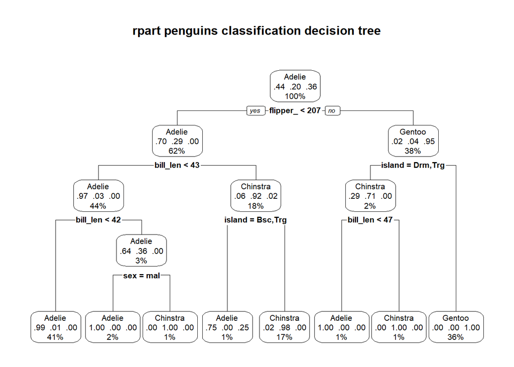

```r
# graph the decision tree
prp(pg.rpart, main="rpart penguins classification decision tree", type=2, extra=104, fallen.leaves=TRUE, roundint=FALSE)
```

[figure not shown]

```r
plot(as.party(pg.rpart),"rpart penguins classification decision tree")
```

```r
rpart.rules(pg.rpart, roundint=FALSE)
```

|  | species | Adel Chin Gent |  |  |  |  |  |  |  |  |  |  |  |  |  |  |  |  |  |  |
| --- | --- | --- | --- | --- | --- | --- | --- | --- | --- | --- | --- | --- | --- | --- | --- | --- | --- | --- | --- | --- |
| 10 | Adelie | [ .75 .00 .25] | when | flipper_length_mm | < | 207 | & | bill_length_mm | >= |  |  | 43 | & | island | is | Biscoe or Torgersen |  |  |  |  |
| 8 | Adelie | [ .99 .01 .00] | when | flipper_length_mm | < | 207 | & | bill_length_mm | < | 42 |  |  |  |  |  |  |  |  |  |  |
| 18 | Adelie | [1.00 .00 .00] | when | flipper_length_mm | < | 207 | & | bill_length_mm | is | 42 | to | 43 |  |  |  |  | & | sex | is | male |
| 12 | Adelie | [1.00 .00 .00] | when | flipper_length_mm | >= | 207 | & | bill_length_mm | < | 47 |  |  | & | island | is | Dream or Torgersen |  |  |  |  |
| 11 | Chinstrap | [ .02 .98 .00] | when | flipper_length_mm | < | 207 | & | bill_length_mm | >= |  |  | 43 | & | island | is | Dream |  |  |  |  |
| 19 | Chinstrap | [ .00 1.00 .00] | when | flipper_length_mm | < | 207 | & | bill_length_mm | is | 42 | to | 43 |  |  |  |  | & | sex | is | female |
| 13 | Chinstrap | [ .00 1.00 .00] | when | flipper_length_mm | >= | 207 | & | bill_length_mm | >= |  |  | 47 | & | island | is | Dream or Torgersen |  |  |  |  |
| 7 | Gentoo | [ .00 .00 1.00] | when | flipper_length_mm | >= | 207 |  |  |  |  |  |  | & | island | is | Biscoe |  |  |  |  |

# Decision Tree, Example 3 w/ rpart (train/test)

```r
library(partykit)
library(rpart)
library(rpart.plot)
library(caret)
set.seed(42)

trainIndex = createDataPartition(penguins$species, p=0.8,list=FALSE)
pg.train = penguins[trainIndex,]
pg.test = penguins[-trainIndex,]

pg.rpart <- rpart(species ~ ., data = pg.train, control=rpart.control(xval=10), method="class")

pg.predict <- predict(pg.rpart, pg.test)

pg.rpart$cptable
```

```
##          CP nsplit  rel error    xerror       xstd
## 1 0.6258065      0 1.00000000 1.0000000 0.05330577
## 2 0.2838710      1 0.37419355 0.3741935 0.04368823
## 3 0.0100000      2 0.09032258 0.1290323 0.02779137
```

# Resources

## Descriptions

- [Tree-Based Models (c3.ai)](https://c3.ai/glossary/data-science/tree-based-models/)
- Just Enough R, Chapter 6: Tree Methods (book, 2020)

## Packages

- [J48 (Java implementation of Quinlan’s C4.5)](https://weka.sourceforge.io/doc.dev/weka/classifiers/trees/J48.html)